# 02 Text Embedding and Classification Tasks

Florian Berding, Julia Pargmann, Andreas Slopinski, Elisabeth Riebenbauer, Karin Rebmann

# 1 Introduction and Overview

In the educational and social sciences, the assignment of an observation to scientific concepts is an important task that allows researchers to understand an observation, to generate new insights, and to derive recommendations for research and practice.

In educational science, several areas deal with this kind of task. For example, diagnosing students’ characteristics is an important aspect of a teachers’ profession and necessary to understand and promote learning. Another example is the use of learning analytics, where data about students is used to provide learning environments adapted to their individual needs. On another level, educational institutions such as schools and universities can use this information for data-driven performance decisions (Laurusson & White 2014) as well as where and how to improve it. In any case, a real-world observation is aligned to scientific models to use scientific knowledge as a technology for improved learning and instruction.

Supervised machine learning is one concept that allows a link between real-world observations and existing scientific models and theories (Berding et al. 2022). For educational sciences this is a great advantage because it allows researchers to use the existing knowledge and insights for applications of AI. The drawback of this approach is that the training of AI requires both information about the real world observations and information on the corresponding alignment with scientific models and theories.

A valuable source of data in educational science are written texts, since textual data can be found almost everywhere in the realm of learning and teaching (Berding et al. 2022). For example, teachers often require students to solve a task which they provide in a written form. Students have to create a solution for the tasks which they often document with a short-written essay or a presentation. This data can be used to analyze learning and teaching. Teachers’ written tasks for their students may provide insights into the quality of instruction while students’ solutions may provide insights into their learning outcomes and prerequisites.

AI can be a helpful assistant in analyzing textual data since the analysis of textual data is a challenging and time-consuming task for humans. In this vignette, we would like to show how to create an AI that can help you with such tasks by using the package *aifedcuation*.

**Please note that an introduction to content analysis, natural language processing or machine learning is beyond the scope of this vignette. If you would like to learn more, please refer to the cited literature.**

Before we start it is necessary to introduce a definition of our understanding of some basic concepts since applying AI to educational contexts means to combine the knowledge of different scientific disciplines using different, sometimes overlapping concepts. Even within a research area, concepts are not unified. Figure 1 illustrates this package’s understanding.

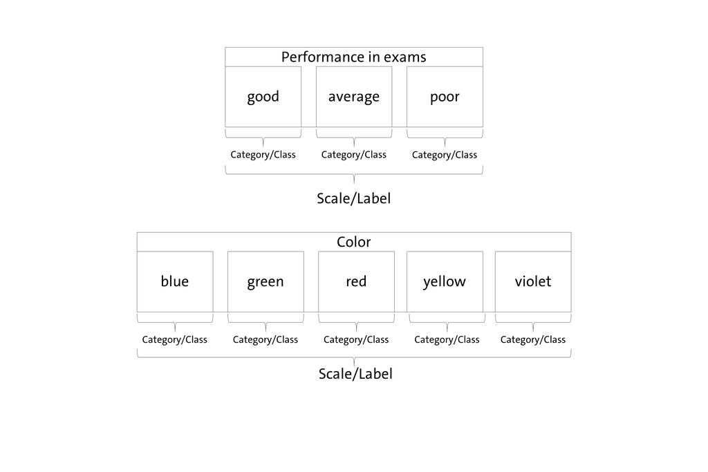

Figure 1: Understanding of Central Concepts

Since *aifeducation* looks at the application of AI for classification tasks from the perspective of the empirical method of content analysis, there is some overlapping between the concepts of content analysis and machine learning. In content analysis, a phenomenon like performance and colors can be described as a scale/dimension which is made up by several categories (e.g. Schreier 2012 pp. 59). In our example, an exam’s performance (scale/dimension) could be “good”, “average” or “poor”. In terms of colors (scale/dimension) categories could be “blue”, “green”, etc. Machine learning literature uses other words to describe this kind of data. In machine learning, “scale” and “dimension” correspond to the term “label” while “categories” refer to the term “classes” (Chollet, Kalinowski & Allaire 2022, p. 114).

With these clarifications, classification means that a text is assigned to the correct category of a scale or that the text is labeled with the correct class. As Figure 2 illustrates, two kinds of data are necessary to train an AI to classify text in line with supervised machine learning principles.

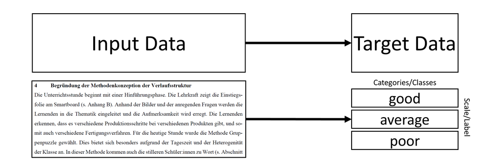

Figure 2: Basic Structure of Supervised Machine Learning

By providing AI with both the textual data as input data and the corresponding information about the class as target data, AI can learn which texts imply a specific class or category. In the above exam example, AI can learn which texts imply a “good”, an “average” or a “poor” judgment. After training, AI can be applied to new texts and predict the most likely class of every new text. The generated class can be used for further statistical analysis or to derive recommendations about learning and teaching.

To achieve this support by an artificial intelligence, several steps are necessary. Figure 3 provides an overview integrating the functions and objects of *aifeducation*.

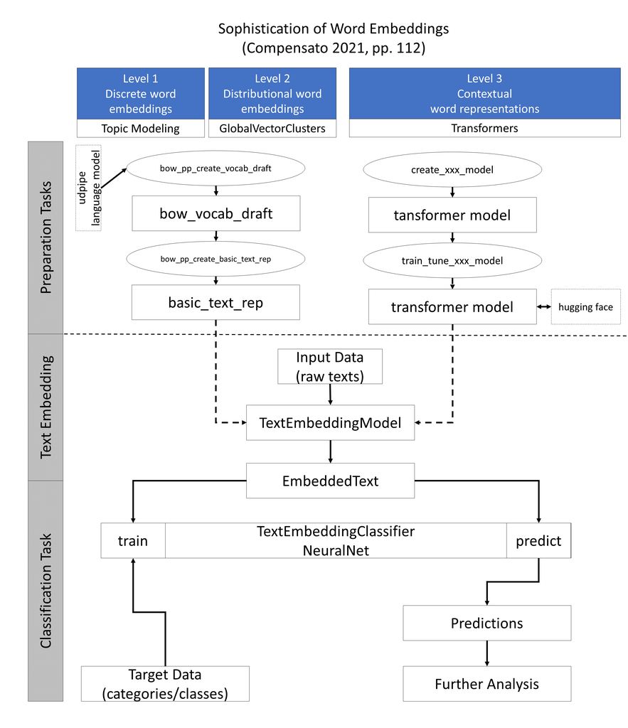

Figure 3: Overview of the Steps to Perform a Classification

The first step is to transform raw texts into a form computers can use. That is, the raw texts must be transformed into numbers. In modern approaches, this is usually done through word embeddings. Campesato (2021, p. 102) describes them as “the collective name for a set of language modeling and feature learning techniques (…) where words or phrases from the vocabulary are mapped to vectors of real numbers.” The definition of a word vector is similar: „Word vectors represent the semantic meaning of words as vectors in the context of the training corpus.” (Lane, Howard & Hapke 2019, p. 191)

Campesato (2021, pp. 112) clusters approaches for creating word embeddings into three groups, reflecting their ability to provide context-sensitive numerical representations. Approaches in group one do not account for any context. Typical methods rely on bag-of-words assumptions. Thus, they are normally not able to provide a word embedding for single words. Group two consists of approaches such as word2vec, GloVe (Pennington, Socher & Manning 2014) or fastText, which are able to provide one embedding for each word regardless of its context. Thus, they only account for one context. The last group consists of approaches such as BERT (Devlin et al. 2019), which are able to produce multiple word embeddings depending on the context of the words.

From these different groups, *aifedcuation* implements several methods.

- **Topic Modeling:** Topic modeling is an approach that uses frequencies of tokens within a text. The frequencies of the tokens are models as the observable variables of one more latent topic (Campesato 2021, p. 113). The estimation of a topic model is often based on a Latent Dirichlet Analysis (LDA) which describes each text by a distribution of topics. The topics themselves are described by a distribution of words/tokens (Campesato 2021, p. 114). This relationship between texts, words, and topics can be used to create a text embedding by computing the relative amount of every topic in a text based on every token in a text.
- **GlobalVectorClusters:** GlobalVectors is a newer approach which utilizes the co-occurrence of words/tokens to compute GlobalVectors (Campesato 2021, p. 110). These vectors are generated in a way that tokens/words with a similar meaning are located close to each other (Pennington, Socher & Manning 2014). In order to create a *text* embedding from *word* embeddings, *aifeducation* groups tokens into clusters based on their vectors. Thus, tokens with a similar meaning are members of the same cluster. For the *text* embedding, the tokens of a text are counted for every cluster and the frequencies of every cluster for that text are used as a numerical representation of that text.
- **Transformers:** Transformers are the current state-of-the-art approach for many natural language tasks (Tunstall, von Werra & Wolf 2022, p. xv). With the help of the self-attention mechanism (Vaswani et al. 2017), they are able to produce context-sensitive *word* embeddings (Chollet, Kalinowski & Allaire, 2022 pp.366).

All the approaches are managed and used with a unified interface provided by the object `TextEmbeddingModel`. With this object you can easily convert raw texts into a numerical representation, which you can use for different classification tasks at the same time. This makes it possible to reduce computational time. The created text embedding is stored in an object of class `EmbeddedText`. This object additionally contains information about the text embedding model that created this object.

In the very best case you can apply an existing text embedding model by using a transformer from [Huggingface](https://huggingface.co/) or by using a model from colleagues. If not, *aifeducation* provides several functions allowing you to create your own models. Depending on the approach you would like to use, different steps are necessary. In the case of Topic Modeling or GlobalVectorClusters, you must first create a draft of a vocabulary with the two functions `bow_pp_create_vocab_draft()` and `bow_pp_create_basic_text_rep()`. When calling these functions, you determine central properties of the resulting model. In the case of transformers, you first have to configure and to train a vocabulary with `create_xxx_model()` and in a next step you can train your model with `train_tune_xxx_model()`. Every step will be explained in the next chapters. Please note that `xxx` stands for different architectures of transformers that are supported with *aifedcuation*.

With an object of class `TextEmbeddingModel` you can create the input data for the supervised machine learning process. Additionally, you need the target data which must be a named factor containing the classes/categories of each text.

In the next chapters, we will guide you through the complete process, starting with the creation of the text embedding models.

**Please note that the creation of a new text embedding model is only necessary if you cannot rely on an existing model or if you cannot rely on a pre-trained transformer.**

# 2 Start Working

# 2.1 Starting a New Session

Before you can work with *aifeducation* you must set up a new *R* session. First, it is necessary that you load the library. Second, you must set up python via reticulate. In case you installed python as suggested in vignette 01 Get started you may start a new session like this:

```r
reticulate::use_condaenv(condaenv = "aifeducation")
library(aifeducation)
```

Next you have to choose the machine learning framework you would like to use. You can set the framework for the complete session with

```r
#For tensorflow
aifeducation_config$set_global_ml_backend("tensorflow")
set_transformers_logger("ERROR")

#For PyTorch
aifeducation_config$set_global_ml_backend("pytorch")
set_transformers_logger("ERROR")
```

In the case that you would like to use tensorflow now is a good time to configure that backend, since some configurations can only be done **before** tensorflow is used the first time.

```r
#if you would like to use only cpus
set_config_cpu_only()

#if you have a graphic device with low memory
set_config_gpu_low_memory()

#if you would like to reduce the tensorflow output to errors
set_config_os_environ_logger(level = "ERROR")
```

> **Note:** Please remember: Every time you start a new session in *R* you have to to set the correct conda environment, to load the library *aifeducation*, and to chose your machine learning framework.

# 2.2 Reading Texts into *R*

For most applications of *aifeducation* it’s necessary to read the text you would like to use into *R*. For this task, several packages are available on CRAN. Our experience has been good with the package readtext since it allows you to process different kind of sources for textual data. Please refer to readtext’s documentation for more details. If you have not installed this package on your machine, you can request it by

```r
install.packages("readtext")
```

For example, if you have stored your texts in an excel sheet with two columns (*texts* for the texts and *id* for the texts’ id) you can read the data by

```r
#for excel files
textual_data<-readtext::readtext(
  file="text_data.xlsx",
  text_field = "texts",
  docid_field = "id"
)
```

Here it is crucial that you pass the file path to `file` and the name of the column for the texts to `text_field` and the name of the column for the id to `docid_field`.

In other cases you may have stored each text in a separate file (e.g., .txt or .pdf). For these cases you can pass the directory of the files and read the data. In the following example the files are stored in the directory “data”.

```r
#read all files with the extension .txt in the directory data
textual_data<-readtext::readtext(
  file="data/*.txt"
)

#read all files with the extension .pdf in the directory data
textual_data<-readtext::readtext(
  file="data/*.pdf"
)
```

If you read texts for sever files you do not need to specify the arguments `docid_field` and `text_field`. The id of the texts is automatically set to the file names.

Please refer to the documentation of the function readtext within the readtext library for more information.

Now everything is ready to start the preparation tasks.

# 3 Preparation Tasks

## 3.1 Example Data for this Vignette

To illustrate the steps in this vignette, we cannot use data from educational settings since these data is generally protected by privacy policies. Therefore, we use the data set `data_corpus_moviereviews` from the package quanteda.textmodels to illustrate the usage of this package. This quanteda.textmodels is automatically installed when you install *aifeducation*.

```r
example_data<-data.frame(
  id=quanteda::docvars(quanteda.textmodels::data_corpus_moviereviews)$id2,
  label=quanteda::docvars(quanteda.textmodels::data_corpus_moviereviews)$sentiment)
example_data$text<-as.character(quanteda.textmodels::data_corpus_moviereviews)

table(example_data$label)
```

```
#>
#>  neg  pos
#> 1000 1000
```

We now have a data set with three columns. The first contains the ID of the movie review, the second contains the rating of the movie (positive or negative), and the third column contains the raw texts. As you can see, the data is balanced. About 1,000 reviews imply a positive rating of a movie and about 1,000 imply a negative rating.

For this tutorial, we modify this data set by setting about half of the negative and positive reviews to `NA`, indicating that these reviews are not labeled.

```r
example_data$label[c(1:500,1001:1500)]=NA
summary(example_data$label)
```

```
#>  neg  pos NA's
#>  500  500 1000
```

Furthermore, we will bring some imbalance by setting 250 positive reviews to `NA`.

```r
example_data$label[1501:1750]=NA
summary(example_data$label)
```

```
#>  neg  pos NA's
#>  500  250 1250
```

We will now use this data to show you how to use the different objects and functions in *aifeducation*.

## 3.2 Topic Modeling and GlobalVectorClusters

If you would like to create a new text embedding model with Topic Modeling or GlobalVectorClusters, you first have to create a draft of a vocabulary. You can do this by calling the function `bow_pp_create_vocab_draft()`. The main input of this function is a vector of texts. The function’s aims are

- to create a list of all tokens of the texts,
- to reduce the tokens to tokens that carry semantic meaning,
- to provide the lemma of every token.

Since Topic Modeling depends on a bag-of-word approach, the reason for this pre-process step is to reduce the tokens to tokens that really carry semantic meaning. In general, these are tokens of words that are either nouns, verbs or adjectives (Papilloud & Hinneburg 2018, p. 32). With our example data, an application of that function could be:

```r
vocab_draft<-bow_pp_create_vocab_draft(
  path_language_model="language_model/english-gum-ud-2.5-191206.udpipe",
  data=example_data$text,
  upos=c("NOUN", "ADJ","VERB"),
  label_language_model="english-gum-ud-2.5-191206",
  language="english",
  trace=TRUE)
```

As you can see, there is an additional parameter: `path_language_model`. Here you must insert the path to an udpipe pre-trained language model since this function uses the *udpipe* package for part-of-speech tagging and lemmataziation. A collection of pre-trained models for about 65 languages can be found here [https://lindat.mff.cuni.cz/repository/xmlui/handle/11234/1-3131]. Just download the relevant model to your machine and provide the path to the model.

With the parameter `upos` you can select which tokens should be selected. In this example, only tokens that represent a noun, an adjective or a verb will remain after the analysis. A list of possible tags can be found here: [https://universaldependencies.org/u/pos/index.html].

Please do not forget do provide a label for the udpipe model you use and please also provide the language you are analyzing. This information is important since this will be transferred to the text embedding model. Other researchers/users will need this information to decide if this model could help with their own work.

In the next step, we can use our draft of a vocabulary to create a basic text representation with the function `bow_pp_create_basic_text_rep()`. This function takes raw texts and the draft of a vocabulary as main input. The function aims

- to remove tokens referring to stopwords,
- to clean the data (e.g., removing punctuation, numbers),
- to lower case all tokens if requested,
- to remove tokens with a specific minimal frequency,
- to remove tokens that occur in too few or too many documents
- to create a document-feature-matrix (dfm),
- to create a feature-co-occurrence-matrix (fcm).

Applied to the example, the call of the function could look like this:

```r
basic_text_rep<-bow_pp_create_basic_text_rep(
  data = example_data$text,
  vocab_draft = vocab_draft,
  remove_punct = TRUE,
  remove_symbols = TRUE,
  remove_numbers = TRUE,
  remove_url = TRUE,
  remove_separators = TRUE,
  split_hyphens = FALSE,
  split_tags = FALSE,
  language_stopwords="eng",
  use_lemmata = FALSE,
  to_lower=FALSE,
  min_termfreq = NULL,
  min_docfreq= NULL,
  max_docfreq=NULL,
  window = 5,
  weights = 1 / (1:5),
  trace=TRUE)
```

`data` takes the raw texts while `vocab_draft` takes the draft of a vocabulary we created in the first step.

The main goal is to create a document-feature-matrix(dfm) and a feature-co- occurrence-matrix (fcm). The dfm is a matrix that reports the texts in the rows and the number of tokens in the columns. This matrix is later used to create a text embedding model based on topic modeling. The dfm is reduced to tokens that correspond to the part-of-speech tags of the vocabulary draft. Punctuation, symbols, numbers etc. are removed from this matrix if you set the corresponding parameter to `TRUE`. If you set `use_lemmata = TRUE` you can reduce the dimensionality of this matrix further by using the lemmas instead of the tokens (Papilloud & Hinneburg 2018, p.33). If you set `to_lower = TRUE` all tokens are transformed to lower case. At the end you get a matrix that tries to represent the semantic meaning of the text with the smallest possible number of tokens.

The same applies for the fcm. Here, the tokens/features are reduced in the same way. However, before the features are reduced, the token’s co-occurrence is calculated. For this aim a window is used and shifted across the text, counting the tokens left and right from the token under investigation. The size of this window can be determined with `window`. With `weights` you can provide weights for counting. For example, the tokens which are far away from the token under investigation count less than tokens that are closer to the token under investigation. The fcm is later used to create a text embedding model based on GlobalVectorClusters.

As you may notice, the dfm only counts the words in a text. Thus, their position in the text or within a sentence does not matter. If you further lower-case tokens or use lemmas, more syntactic information is lost for the advantage that the dfm has a lower dimensionality while losing only little semantic meaning. In contrast, the fcm is a matrix that describes how often different tokens occur together. Thus, an fcm recovers part of the position of words in a sentence and in a text.

Now, everything is ready to create a new text embedding model based on Topic Modeling or GlobalVectorClusters. Before we show you how to create the new model, we will have a look on the preparation of a new transformer.